# Network based multifactorial modelling microRNA-target interaction.

## Methods

### Construction of miRNA:target network

miRNA and target pairs per line should be provided as edge list to construct the network. At each line minimum required information is expression levels of miRNA and the target. If available, additional data about factors effecting binding or efficiency of miRNA can be provided as separate columns. After construction of the network, amount of miRNA per target is calculated and kept as edge data. Simply, a target will sequester miRNA proportional to its ratio amount among other targets. If additional criteria effecting the binding of miRNA to its target is provided, distribution of miRNA will be calculated accordingly. Target can be mRNA or any other ceRNA (circRNA, ncRNA, etc.) thus, throughout the manuscript terms target, gene and ceRNA are used interchangeably.

### Triggering perturbation and subsequent calculations

Initially, the network is assumed in steady-state (a) condition and needs a trigger for initiating calculations. The trigger can be a change in expression level of one or more genes (b). After a trigger, the network undergoes iterative cycle of calculations at each of which distribution of miRNA in local neighborhood is recalculated (c). Based on new miRNA distribution, expression level of each node (i.e. ceRNA) is updated. Due to nodes which are targeted by multiple miRNAs, the change in one neighborhood spreads to other neighborhoods (d), consequently have potential to effect whole network due to “ripple effect”.

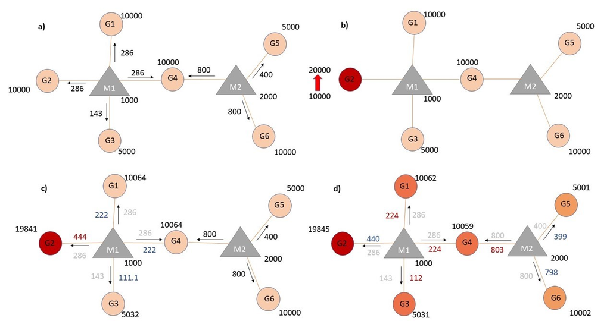

Schematic presentation of mechanism of network based model. a) In steady state, miRNAs (M: gray triangle) repress targets (G: circle coconut) according to proportion of their targets’ expression. b) Two fold increase in transcript level of Gene2 (G2) acts as a trigger. c) Distribution of miRNA1 (M1) changes. d) The change at expression of common target effects changes of proportional distribution of miRNA2 (M2). Expression values are rounded to integers for simplicity

During calculations, following assumptions were adopted; 1) Transcription and degradation rates of miRNAs are steady and equal. 2) All available miRNAs are recycled as in miRNA:ceRNA binding, target is degraded and miRNA is unaffected. 3) ceRNA targets also have stable transcription and degradation rates and these rates are equal.

$$\begin{equation}
Eff_{gi}= C_m \times C_{gi}/\sum_{1}^{i} C_g \tag{1}\label{eq:1}
\end{equation}$$
$$\begin{equation}
R_{gi}= Eff_{i1} + Eff_{i2} ... \tag{2}\label{eq:2}
\end{equation}$$

### Multifactorial calculations in miRNA:target network

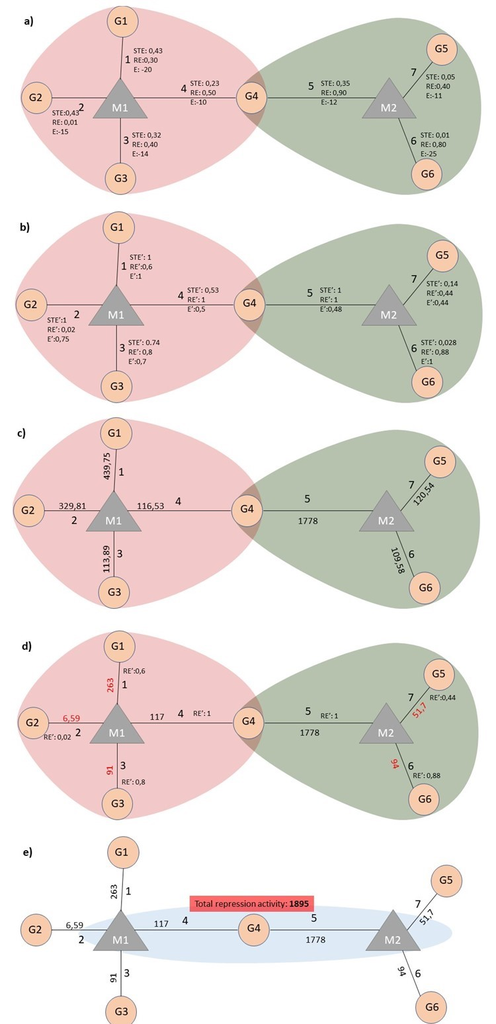

Calculations to determine of miRNA binding and repression efficiency. $G$, Gene; $M$, miRNA; $STE$, seed type effect; $RE$, Region Effect; $E$, Energy; $STE^\prime$, normalized values of seed type efficiency coefficient; $RE^\prime$, normalized values of region efficiency coefficient; $E^\prime$, normalized values of energy coefficient.

After miRNA binds to its target, but might not repress to bound target. The functionality of bound miRNA on target depends on efficiency factors like region that is binding sequence of miRNA on its target. Exact repression efficiency of miRNA is calculated according to equation (d); $RE^\prime_{gi}$, normalized values of region efficiency coefficient between miRNA and gene. The cooperative repression activity of miRNAs to their common targets is figured out as shown in e.